# Part 2 Social Care Survey Open Data

```r
load("wrangled_datasets.RData")
library(tidyverse)
library(forcats)
library(cowplot)
```

# Introduction

In part 1 of the open data project I imported and wrangled the data into the required format. In this part I will focus on the 2010 data and describe the distribution and missingness of the variables in the dataset for this year. It is important to remember that the 2010 data only reports on home care with observations of about 76,000 individuals. 2011 and 2012 data also reports on telecare which adds 3 variables but doubles the observations.

# 2010 descriptives

I’ll start with age.

## Age and Missing Data

### National distribution

First of all I’ll visualise the distribution home care received by age across the country. The open data release pre-banded this variable into 5 categories.

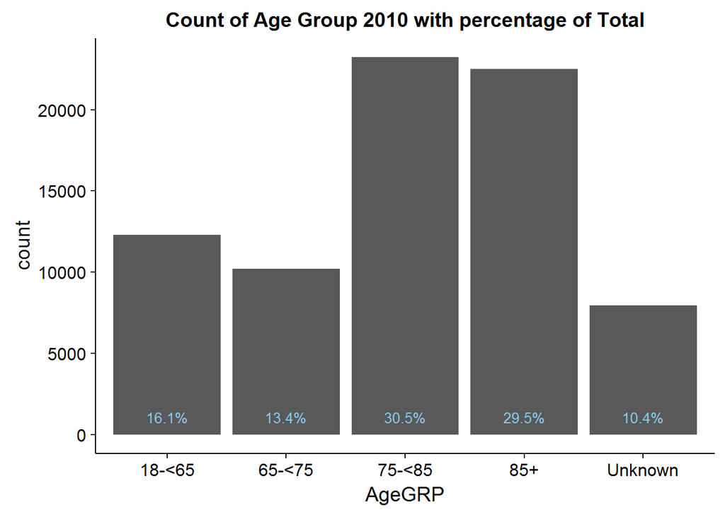

```r
AgeGRP10stats <-                       #Create a table with summary stats to use as labels
  hmcare2010 %>%                       #in the plot
  group_by(AgeGRP) %>%                 #Group main df by Age
  summarise(count = n()) %>%           #Count individuals in each age group - new column
  mutate(pct = count/sum(count)*100)   #New column - with percentage calculated

age_plot_national <-                   #Plot Age group from main hmcare2010 df.
  ggplot(hmcare2010,aes(x = AgeGRP)) +
  geom_bar() +
  geom_text(data = AgeGRP10stats, aes(label=paste0(round(pct,1),"%"), #Add labels from above
                               y=pct), size=3.5, vjust = -1, colour = "sky blue") +
  ggtitle("Count of Age Group 2010 with percentage of Total")
age_plot_national
```

The HCclient variable is a dichotomous variable signifying whether an individual gets home care or not. If not, then the individual only gets some other form of care i.e. meals, laundry etc. I wondered if there was an age difference between these 2 groups.

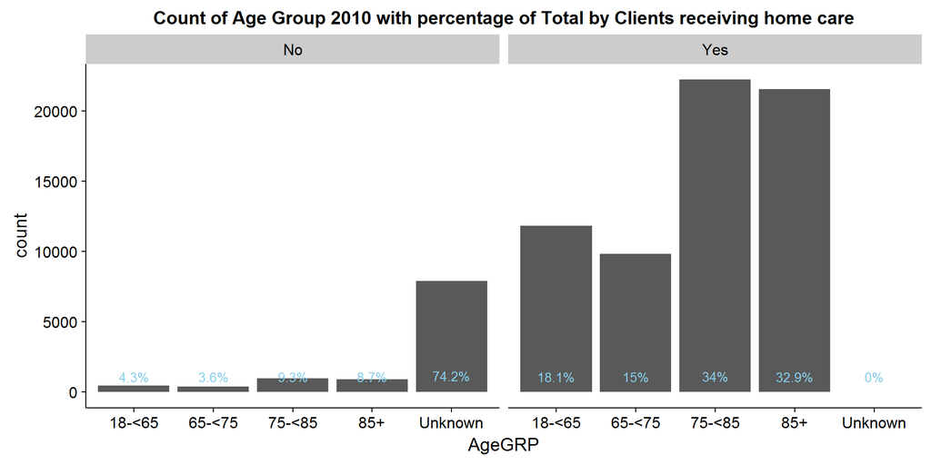

```r
AgeGRP_HC10stats <-                      #As 2010_age_plot chunk above
  hmcare2010 %>%
  group_by(HCclient, AgeGRP) %>%         #with df grouped by HCclient - home care or not
  summarise(count = n()) %>%
  mutate(pct = count/sum(count)*100)

age_plot_national_HCclient <-            #Same plot as 2010_age_plot chunk
  ggplot(hmcare2010,aes(x = AgeGRP)) +
  geom_bar() +
  facet_wrap(~HCclient) +                #with facet of HCclient added
  geom_text(data = AgeGRP_HC10stats, aes(label=paste0(round(pct,1),"%"),
                               y=pct), size=3.5, vjust = -1, colour = "sky blue") +
  ggtitle("Count of Age Group 2010 with percentage of Total by Clients receiving home care")
age_plot_national_HCclient
```

Ok, good to know - of those clients that receive home care we have virtually no missing data. The plot shows 0% but there are a few - we can code to find out how many…

```r
hmcare2010 %>%
  filter(HCclient == "Yes") %>%
  filter(AgeGRP == "Unknown") %>%
  summarise(n())
```

```
##   n()
## 1  13
```

13 individuals. Out of a total of 65515.

Conversely, almost 75% of the 10687 individuals who do not receive home care have Age data missing. I suspect the missing data will all be in the the non-home care individuals. To enable me to assess these subsets seperately I will create 2 new dataframes, One of clients with home care hours and one with clients that receive no home care hours.

```r
hmcare_only2010 <-           #Create new object "hmcare_only2010" that filters by all
  hmcare2010 %>%             #individuals from hmcare2010 that have HCclient == "Yes"
  filter(HCclient == "Yes")  #i.e. all those that receive home care hours.

no_hmcare2010 <-             #Create a new object "no_hmcare2010" which contains the
  hmcare2010 %>%             #individuals not in hmcare_only2010
  filter(HCclient == "No")
```

### Missing data

Ok, I’d like to prove my point about the missing data being in the no home care cohort so we’lll start with this. I’ll have a quick look at the dataframe to start with.

```r
glimpse(no_hmcare2010)
```

```
## Observations: 10,687
## Variables: 19
## $ LAcode            <fctr> Aberdeen City, Aberdeen City, Aberdeen City...
## $ clientID          <chr> "ZZXJX", "Z3BO7", "8BW1I", "6SV86", "OL19L",...
## $ AgeGRP            <fctr> Unknown, Unknown, Unknown, Unknown, Unknown...
## $ ClientGRP         <fctr> Blank, Blank, Blank, Blank, Blank, Blank, B...
## $ GenderISO         <fctr> Blank, Blank, Blank, Blank, Blank, Blank, B...
## $ meals             <fctr> Meals, Meals, Meals, Meals, Meals, Meals, M...
## $ bandHRSLA         <fctr> Zero, Zero, Zero, Zero, Zero, Zero, Zero, Z...
## $ bandHRSpri        <fctr> Zero, Zero, Zero, Zero, Zero, Zero, Zero, Z...
## $ bandHRSvol        <fctr> Zero, Zero, Zero, Zero, Zero, Zero, Zero, Z...
## $ bandHRSPC         <fctr> Zero, Zero, Zero, Zero, Zero, Zero, Zero, Z...
## $ bandHRSTT         <fctr> Zero, Zero, Zero, Zero, Zero, Zero, Zero, Z...
## $ HCclient          <fctr> No, No, No, No, No, No, No, No, No, No, No,...
## $ LivingArr         <fctr> NA, NA, NA, NA, NA, NA, NA, NA, NA, NA, NA,...
## $ Staff             <fctr> Single Staff, Single Staff, Single Staff, S...
## $ HousingType_OV    <fctr> Mainstream, Mainstream, Mainstream, Mainstr...
## $ Laundry_OV        <fctr> No, No, No, No, No, No, No, No, No, No, No,...
## $ Shopping_OV       <fctr> No, No, No, No, No, No, No, No, No, No, No,...
## $ HousingSupport_OV <fctr> No, No, No, No, No, No, No, No, No, No, No,...
## $ IoRN_OV           <fctr> NA, NA, NA, NA, NA, NA, NA, NA, NA, NA, NA,...
```

So here we can see there are 10687 observations of our 19 variables and the first few observartions for Aberdeen City. The first few observations all receive meals service and have data for staffing (i.e. single staffed) and Housing type but all other variables (AgeGRP, ClientGRP, GenderISO) are missing. This supports my hypothesis re missing data being in this subset. I can check for sure with some easy code. All variables are factors with pre-banded groups so I can count the number of observation with each level of factor easily.

Age

```r
age_table <-
  fct_count(no_hmcare2010$AgeGRP) %>%
  mutate(percentage = n/sum(n)*100)
age_table
```

```
## # A tibble: 5 × 3
##         f     n percentage
##    <fctr> <int>      <dbl>
## 1  18-<65   456   4.266866
## 2  65-<75   384   3.593151
## 3  75-<85   996   9.319734
## 4     85+   925   8.655376
## 5 Unknown  7926  74.164873
```

ClientGRP

```r
ClientGRP_table <-
  fct_count(no_hmcare2010$ClientGRP) %>%
  mutate(percentage = n/sum(n)*100)
ClientGRP_table
```

```
## # A tibble: 7 × 3
##                          f     n  percentage
##                     <fctr> <int>       <dbl>
## 1 Dementia & Mental Health   123  1.15093104
## 2      Learning Disability   163  1.52521755
## 3      Physical Disability   252  2.35800505
## 4     Infirmity due to Age  2219 20.76354449
## 5                    Other     5  0.04678581
## 6                Not Known     0  0.00000000
## 7                    Blank  7925 74.15551605
```

Gender

```r
Gender_table <-
  fct_count(no_hmcare2010$GenderISO) %>%
  mutate(percentage = n/sum(n)*100)
Gender_table
```

```
## # A tibble: 3 × 3
##        f     n percentage
##   <fctr> <int>      <dbl>
## 1   Male   815   7.626088
## 2 Female  1947  18.218396
## 3  Blank  7925  74.155516
```

So almost exactly the same number of missing data across Age, Client group and Gender accounting for 75% of observations in the no_homcare subset. Not the greatest.

For now *I am only going to concentrate on the hmcare_only2010 dataset* i.e. the data for which individuals received some hours of home care. I can come back to the no_homecare later but it is not of most interest presently.

## Home Care Only Age

### National distribution

I’ll replot the Age using the hmcare_only2010 subset.

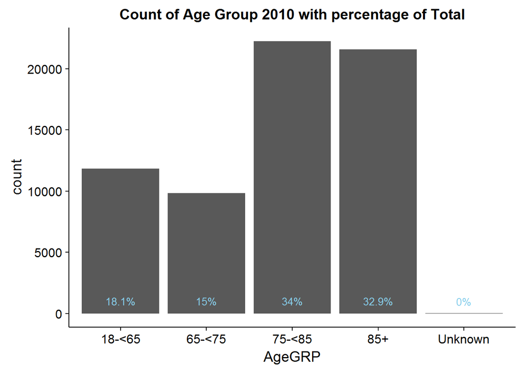

```r
AgeGRP10stats <-                       #Create a table with summary stats to use as labels
  hmcare_only2010 %>%                  #in the plot
  group_by(AgeGRP) %>%                 #Group main df by Age
  summarise(count = n()) %>%           #Count individuals in each age group - new column
  mutate(pct = count/sum(count)*100)   #New column - with percentage calculated

hmcare_only_age_national <-            #Plot Age group from main hmcare_only2010 df.
  ggplot(hmcare_only2010, aes(x = AgeGRP)) +
  geom_bar() +
  geom_text(data = AgeGRP10stats, aes(label=paste0(round(pct,1),"%"), #Add labels from above
                               y=pct), size=3.5, vjust = -1, colour = "sky blue") +
  ggtitle("Count of Age Group 2010 with percentage of Total")
hmcare_only_age_national
```

So 67% of Home care is for people over the age of 75. Again, as we know, there are 13 individuals with missing data for age. We’ll keep them in analyses for now. What does distribution look like across Local Authorities?

### Distribution by Local Authority

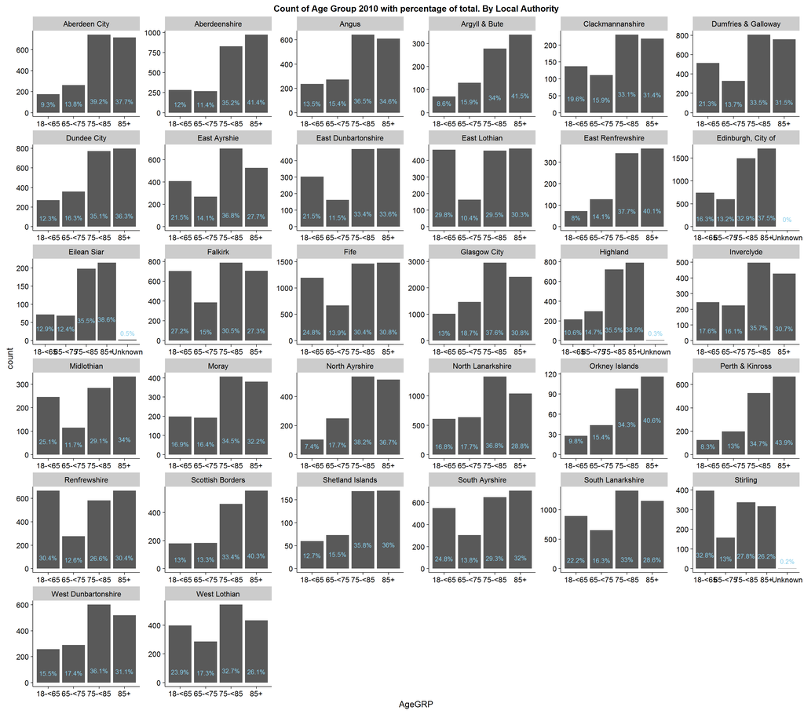

```r
AgeGRP10stats_byLA <-             #Again pre-summarise in a dataframe for labelling
  hmcare_only2010 %>%             #purposes
  group_by(LAcode, AgeGRP) %>%    #Add LA to grouping
  summarise(count = n()) %>%      #Count users by LA and Age Group
  mutate(pct=count/sum(count)*100)    #Add percentage column

age_plot_LA<-
  ggplot(hmcare_only2010, aes(x=AgeGRP)) +   #Plot
  geom_bar() +
  facet_wrap(~LAcode, scales = "free") + #Add the LA facet
  geom_text(data = AgeGRP10stats_byLA, aes(label=paste0(round(pct,1),"%"), y=pct),
            size=3.5, vjust = -1, colour = "sky blue") + #Using table
  ggtitle("Count of Age Group 2010 with percentage of total. By Local Authority")
age_plot_LA
```

At first glance the spread of older clients doesn’t seem to have a pattern - I had expected larger proportions in rural LAs. I’ll try a stacked bar chart.

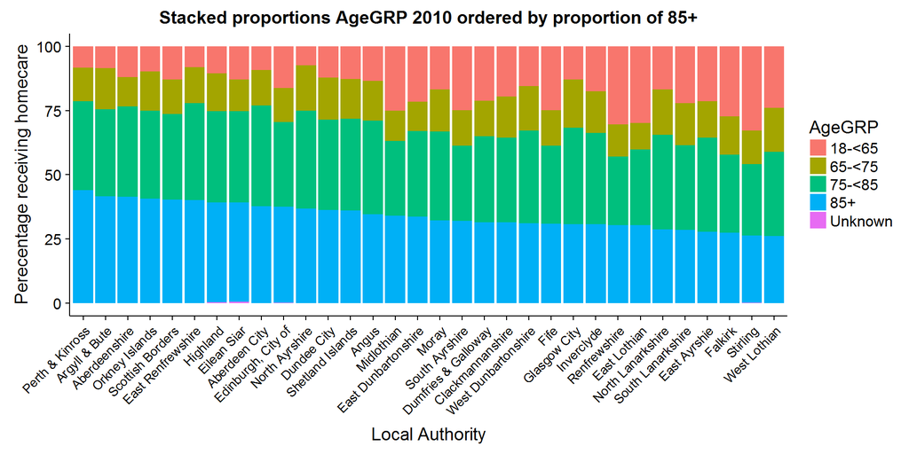

```r
ordered_age <-                               #Create a vector with LAs ordered by over 75s
  AgeGRP10stats_byLA %>%
  arrange(AgeGRP, -pct)
ordered_LAs <- ordered_age$LAcode[97:128]   #Order by 85+

age_plot_stacked_age_LA <-
  ggplot(ordered_age, aes(x = LAcode, y = pct, fill = AgeGRP)) +
  geom_col(position = "stack") +
  scale_x_discrete(limits = ordered_LAs) +   #using above vector
  theme(axis.text.x = element_text(angle = 45, size = 10, hjust = 1)) +
  ggtitle("Stacked proportions AgeGRP 2010 ordered by proportion of 85+") +
  xlab("Local Authority") +
  ylab("Perecentage receiving homecare")
age_plot_stacked_age_LA
```

So clearly higher proportion of home care clients are 85+ in rural areas. I wonder what it looks like if we collapse the factors to show 75-85 and 85+ together.

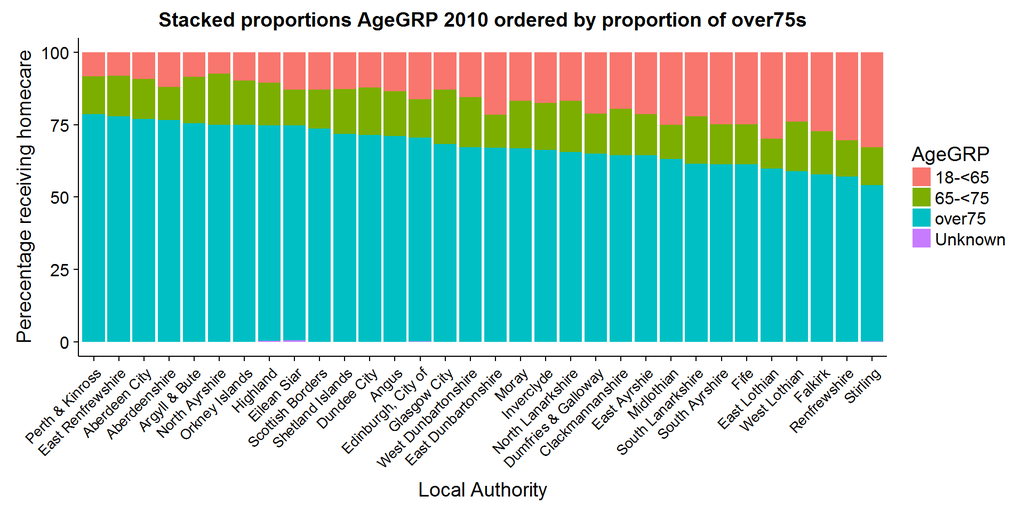

```r
hmcare_only2010_simplified <- hmcare_only2010     #Collapse the 75 - 85 and 85+ levels
hmcare_only2010_simplified$AgeGRP <-              #in a new "simplified" dataframe
  fct_collapse(hmcare_only2010_simplified$AgeGRP,
               over75 = c("75-<85", "85+"))

AgeGRP10stats_byLA_simplified <-              #Create df with new percentage column
  hmcare_only2010_simplified %>%
  group_by(LAcode, AgeGRP) %>%
  summarise(count = n()) %>%
  mutate(pct=count/sum(count)*100)

ordered_age_simplified <-                   #Create a vector with LAs ordered by over 75s
  AgeGRP10stats_byLA_simplified %>%
  arrange(AgeGRP, -pct)
ordered_LAs_simplified <- ordered_age_simplified$LAcode[65:96]

age_plot_stacked_age_LA <-
  ggplot(ordered_age_simplified, aes(x = LAcode, y = pct, fill = AgeGRP)) +
  geom_col(position = "stack") +
  scale_x_discrete(limits = ordered_LAs_simplified) +   #using above vector
  theme(axis.text.x = element_text(angle = 45, size = 10, hjust = 1)) +
  ggtitle("Stacked proportions AgeGRP 2010 ordered by proportion of over75s") +
  xlab("Local Authority") +
  ylab("Perecentage receiving homecare")
age_plot_stacked_age_LA
```

So not much change at the left of the plot, although East Renfrewshire and Aberdeen City have jumped a few places. Interesting to see the 65-75 band does not have much variation. Changes in proportions are tend to be between the 18-65 and over 75 age groups.

## Gender

Next up to to investigate is Gender.

### National Distribution

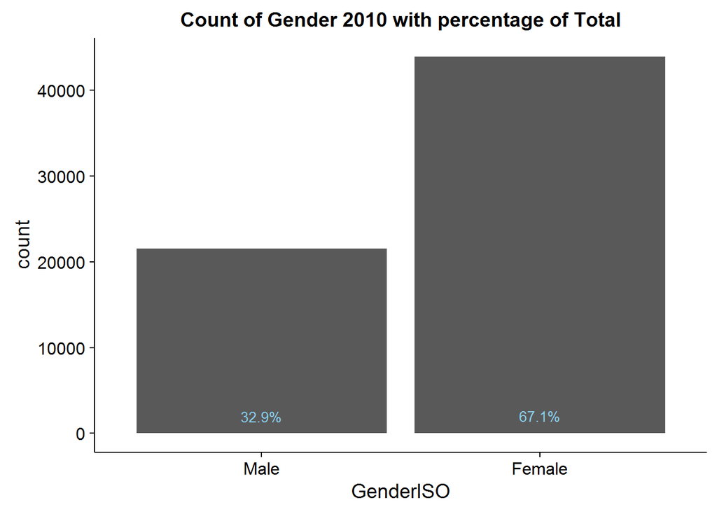

```r
Gender10stats <-
  hmcare_only2010 %>%
  group_by(GenderISO) %>%
  summarise(count = n()) %>%
  mutate(pct = count/sum(count)*100)

gender_plot_national <-
  ggplot(hmcare_only2010, aes(x = GenderISO)) +
  geom_bar() +
  geom_text(data = Gender10stats, aes(label=paste0(round(pct,1),"%"),
                               y=pct), size=3.5, vjust = -1, colour = "sky blue") +
  ggtitle("Count of Gender 2010 with percentage of Total")
gender_plot_national
```

So, I did know there was a split but forgot is was quite as profound as that. This is reported in the annual social care survey. Why do women use more home care? Because they live longer?

### Distribution by Age

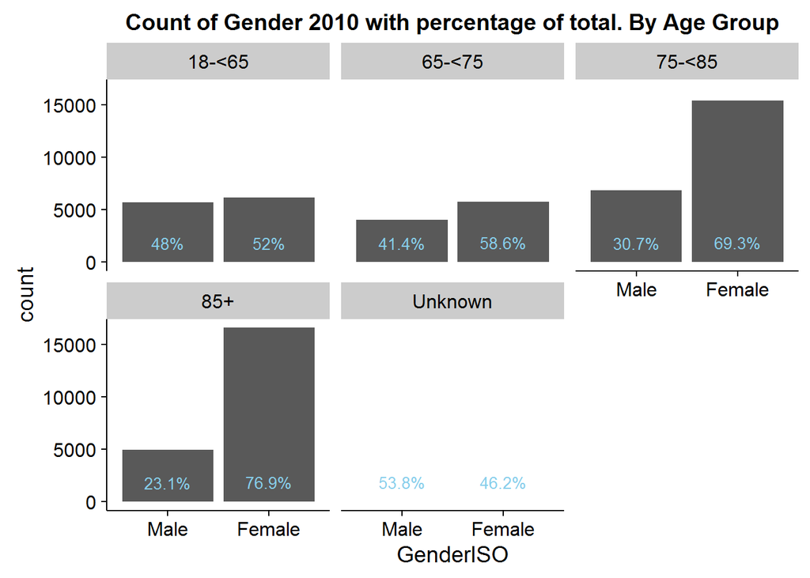

```r
Gender10stats_byAge <-
  hmcare_only2010 %>%
  group_by(AgeGRP, GenderISO) %>%
  summarise(count = n()) %>%
  mutate(pct = count/sum(count) * 100)

gender_plot_age <-
  ggplot(hmcare_only2010, aes(x=GenderISO)) +
  geom_bar() +
  facet_wrap(~AgeGRP) +
  geom_text(data = Gender10stats_byAge, aes(label=paste0(round(pct,1),"%"),
                               y=pct), size=3.5, vjust = -1, colour = "sky blue") +
  ggtitle("Count of Gender 2010 with percentage of total. By Age Group")
gender_plot_age
```

Certainly the difference in proportions of males and females increases thorugh the age bands.

### Distribution by Local Authority

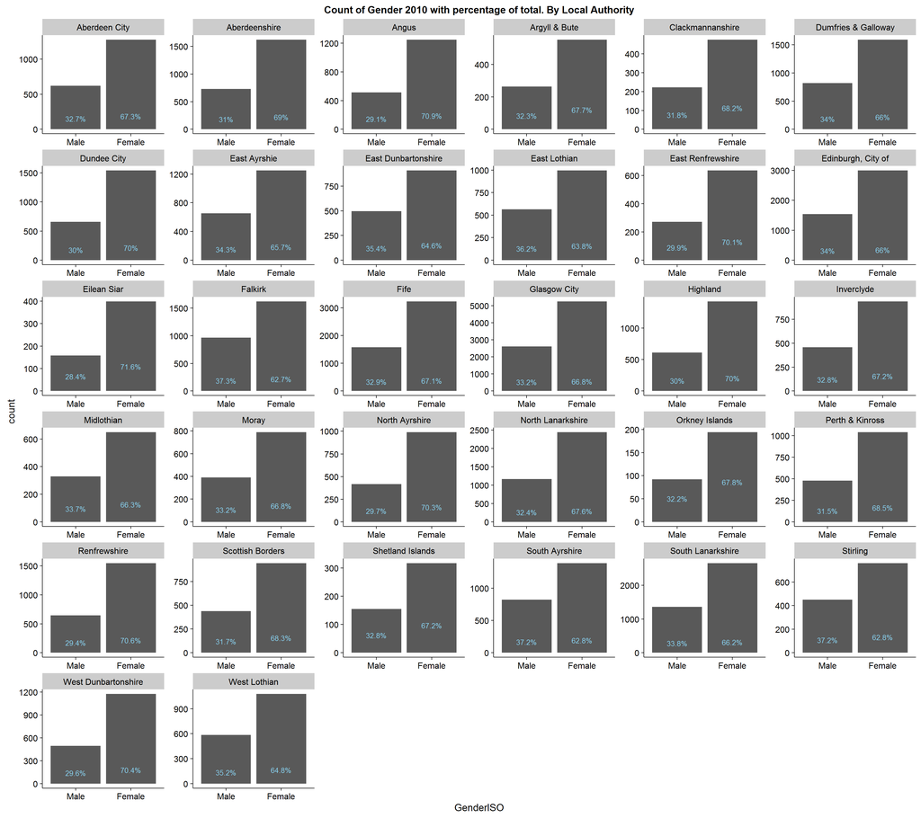

```r
Gender10stats_byLA <-
  hmcare_only2010 %>%
  group_by(LAcode,GenderISO) %>%
  summarise(count = n()) %>%
  mutate(pct = count/sum(count) * 100)

gender_plot_LA <-
  ggplot(hmcare_only2010, aes(x=GenderISO)) +
  geom_bar() +
  facet_wrap(~LAcode, scales = "free") +
  geom_text(data = Gender10stats_byLA, aes(label=paste0(round(pct,1),"%"),
                               y=pct), size=3.5, vjust = -1, colour = "sky blue") +
  ggtitle("Count of Gender 2010 with percentage of total. By Local Authority")
gender_plot_LA
```

Distribution looks pretty consistant across LAs.

## Client Group

Next up in the dataframe is Client Group. Using the metadata file published alongside the open data we can see this variable has been pre-grouped before release - presumably due to small numbers.

- Dementia and Mental Health are combined.
- “Other” is a combination of the Addiction, Palliative Care, Carers, and Other vulnerable groups designations. “Carers” itself is defined as home care provided to aid a family carer.“Other vulnerable groups” includes; HIV/AIDs, Aquired Brain Injury, Homeless, and Women escaping domestic violence.
- The remainin groups are; Learning Disablility, Physical Disability, Problems arising from infirmity due to age.

Published Social Care Survey reports identify the potential for poor classification with this variable. Dementia is known to be underecorded. Also Physical Disability and Infirmity are often misclassified and can often be interchangeable.

### National distribution

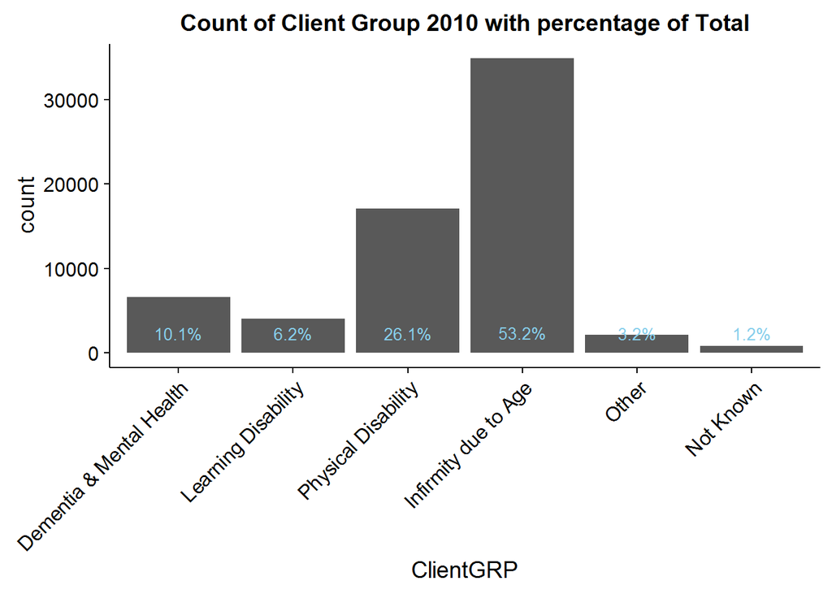

```r
ClientGRP10stats <-
  hmcare_only2010 %>%
  group_by(ClientGRP) %>%
  summarise(count = n()) %>%
  mutate(pct = count/sum(count)*100)

clientGRP_national <-
  ggplot(hmcare_only2010, aes(x = ClientGRP)) +
  geom_bar() +
  geom_text(data = ClientGRP10stats, aes(label=paste0(round(pct,1),"%"),
                               y=pct), size=3.5, vjust = -1, colour = "sky blue") +
  ggtitle("Count of Client Group 2010 with percentage of Total") +
  theme(axis.text.x = element_text(angle = 45, size = 12,hjust = 1))
clientGRP_national
```

So pretty clearly the majority of home care is for Physical Disability and Infirmity - almost 80%. A little more missing data here but only 1.2% of the total.

### Distribution by Age

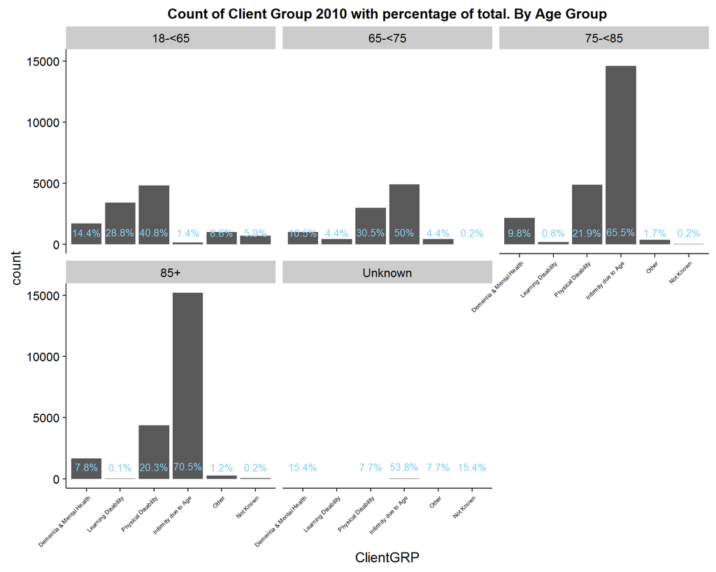

```r
ClientGRPstats_byAge <-
  hmcare_only2010 %>%
  group_by(AgeGRP, ClientGRP) %>%
  summarise(count = n()) %>%
  mutate(pct = count/sum(count) * 100)

clientGRP_byAge <-
  ggplot(hmcare_only2010, aes(x=ClientGRP)) +
  geom_bar() +
  facet_wrap(~AgeGRP) +
  geom_text(data = ClientGRPstats_byAge, aes(label=paste0(round(pct,1),"%"),
                               y=pct), size=3.5, vjust = -1, colour = "sky blue") +
  ggtitle("Count of Client Group 2010 with percentage of total. By Age Group") +
  theme(axis.text.x = element_text(angle = 45, size = 6,hjust = 1))
clientGRP_byAge
```

As expected, there are higher numbers of learning disability in the 18-65 Age band with increasing numbers of Physical Disability and Infirmity through the Age Bands.

### Distribution by Local Authority

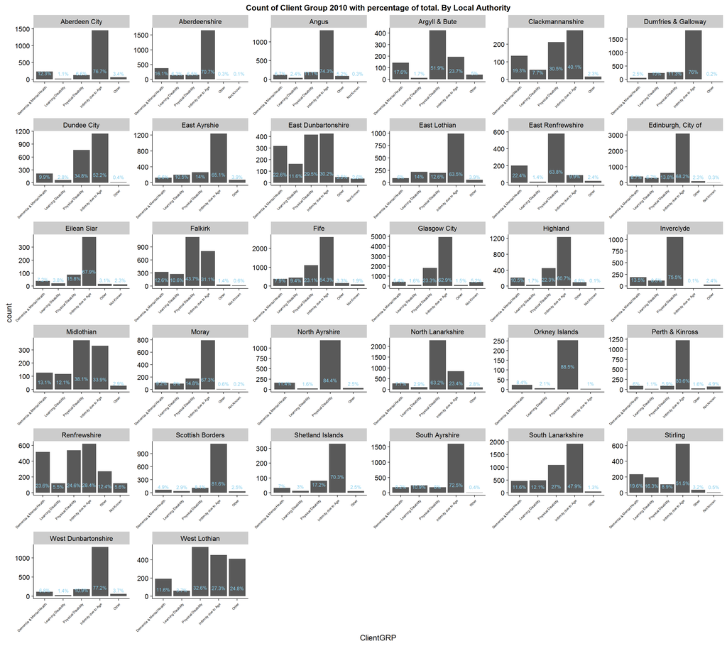

```r
ClientGRP10stats_byLA <-
  hmcare_only2010 %>%
  group_by(LAcode,ClientGRP) %>%
  summarise(count = n()) %>%
  mutate(pct = count/sum(count) * 100)

clientGRP_LA <-
  ggplot(hmcare_only2010, aes(x=ClientGRP)) +
  geom_bar() +
  facet_wrap(~LAcode, scales = "free") +
  geom_text(data = ClientGRP10stats_byLA, aes(label=paste0(round(pct,1),"%"),
                               y=pct), size=3, vjust = -1, colour = "sky blue") +
  ggtitle("Count of Client Group 2010 with percentage of total. By Local Authority")+
  theme(axis.text.x = element_text(angle = 45, size = 6,hjust = 1))
clientGRP_LA
```

So here the facet plot really comes in handy. We can see massive variation in levels of each of the client groups. This is almost certainly down to classification bias - local practices vary on how clients are classified meaning comparison across LAs is impossible. e.g. virtually nobody in North Ayrshire is classified as “Infirmity due to Age”, whilst in the Scottish Borders almost everybody is in this group. This variable would be of no use as a comparator. Missingness seems to be distributed fairly evenly across 13 council areas; Aberdeenshire, Angus, East Dunbartonshire, Edinburgh, City of, Eilean Siar, Falkirk, Fife, Glasgow City, Highland, Moray, Perth & Kinross, Renfrewshire, and Stirling. Renfrewshire has the highest proportion of missing data at 5.6%. To illustrate the variation in classification a little better, let’s use a stacked bar chart again.

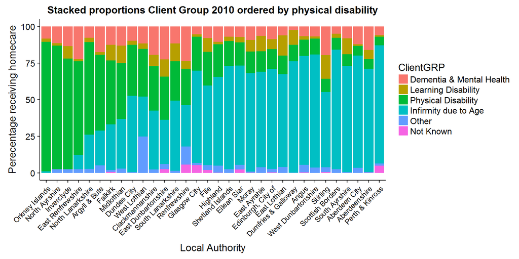

```r
ordered_clientGRP <-
  ClientGRP10stats_byLA%>%
  arrange(ClientGRP, pct)
ordered_LAs_ClientGRP <- ordered_clientGRP$LAcode[65:96]

clientGRP_stacked <-
  ggplot(ClientGRP10stats_byLA, aes(x = LAcode, y = pct, fill = ClientGRP)) +
  geom_col(position = "stack") +
  theme(axis.text.x = element_text(angle = 45, size = 10, hjust = 1)) +
  scale_x_discrete(limits = rev(ordered_LAs_ClientGRP)) +
  ggtitle("Stacked proportions Client Group 2010 ordered by physical disability") +
  xlab("Local Authority") +
  ylab("Perecentage receiving homecare")
clientGRP_stacked
```

So, for example, almost everybody in Aberdeenshire and P & K get home care for Infirmity and hardly anyone for Physical disability, whereas the opposite is true in Orkney and North Ayrshire. Clearly this can’t refelct reality and the issue is with the classification reporting.

## Home Care Hours

```r
PChrs <-
  hmcare_only2010 %>%
  filter(bandHRSPC == "Zero") %>%       #Identify everyone who had Zero value for PC hours
  summarise(n())                        #Count how many observations have this value
PChrs
```

```
##     n()
## 1 65515
```

```r
PChrs == length(hmcare_only2010$bandHRSPC)  #Is the number of observation with Zero equal to the total number of observations in the dataset?
```

```
##       n()
## [1,] TRUE
```

Ok let’s plot the data we do have. I’ll create 4 seperate plots for each variable then combine them into 1 plot.

### National Distribution

```r
bandHRSTT10stats <-
  hmcare_only2010 %>%
  filter(bandHRSTT != "Zero") %>%
  group_by(bandHRSTT) %>%
  summarise(count = n()) %>%
  mutate(pct = count/sum(count)*100)

hmcare_national <-
  hmcare_only2010 %>%
  filter(bandHRSTT != "Zero") %>%
  ggplot(aes(x = bandHRSTT)) +
  geom_bar() +
  geom_text(data = bandHRSTT10stats, aes(label=paste0(round(pct,1),"%"),
                               y=pct), size=2.5, vjust = -1, colour = "sky blue") +
  geom_text(data = bandHRSTT10stats, aes(label=paste0("Total number = ",sum(count)),
                                         x = Inf, y= Inf, hjust = 1, vjust = 3)) +
  ggtitle("Count of Total Home Care Hours 2010") +
  xlab("Number of hours of Home Care") +
  theme(axis.text.x = element_text(angle = 45, size = 12,hjust = 1))
```

```r
bandHRSLA10stats <-
  hmcare_only2010 %>%
  filter(bandHRSLA != "Zero") %>%
  group_by(bandHRSLA) %>%
  summarise(count = n()) %>%
  mutate(pct = count/sum(count)*100)

hmcare_LA <-
  hmcare_only2010 %>%
  filter(bandHRSLA != "Zero") %>%
  ggplot(aes(x = bandHRSLA)) +
  geom_bar() +
  geom_text(data = bandHRSLA10stats, aes(label=paste0(round(pct,1),"%"),
                               y=pct), size=2.5, vjust = -1, colour = "sky blue") +
  geom_text(data = bandHRSLA10stats, aes(label=paste0("Total number = ",sum(count)),
                                         x = Inf, y= Inf, hjust = 1, vjust = 3)) +
  ggtitle("Count of LA provided Home Care Hours 2010") +
  xlab("Number of hours of Home Care") +
  theme(axis.text.x = element_text(angle = 45, size = 12,hjust = 1))
```

```r
bandHRSpri10stats <-
  hmcare_only2010 %>%
  filter(bandHRSpri != "Zero") %>%
  group_by(bandHRSpri) %>%
  summarise(count = n()) %>%
  mutate(pct = count/sum(count)*100)

hmcare_pri <-
  hmcare_only2010 %>%
  filter(bandHRSpri != "Zero") %>%
  ggplot(aes(x = bandHRSpri)) +
  geom_bar() +
  geom_text(data = bandHRSpri10stats, aes(label=paste0(round(pct,1),"%"),
                               y=pct), size=2.5, vjust = -1, colour = "sky blue") +
  geom_text(data = bandHRSpri10stats, aes(label=paste0("Total number = ",sum(count)),
                                         x = Inf, y= Inf, hjust = 1, vjust = 3)) +
  ggtitle("Count of Private provided Home Care Hours 2010") +
  xlab("Number of hours of Home Care") +
  theme(axis.text.x = element_text(angle = 45, size = 12,hjust = 1))
```

```r
bandHRSvol10stats <-
  hmcare_only2010 %>%
  filter(bandHRSvol != "Zero") %>%
  group_by(bandHRSvol) %>%
  summarise(count = n()) %>%
  mutate(pct = count/sum(count)*100)

hmcare_vol<-
  hmcare_only2010 %>%
  filter(bandHRSvol != "Zero") %>%
  ggplot(aes(x = bandHRSvol)) +
  geom_bar() +
  geom_text(data = bandHRSvol10stats, aes(label=paste0(round(pct,1),"%"),
                               y=pct), size=2.5, vjust = -1, colour = "sky blue") +
  geom_text(data = bandHRSvol10stats, aes(label=paste0("Total number = ",sum(count)),
                                         x = Inf, y= Inf, hjust = 1, vjust = 2)) +
  ggtitle("Count of Voluntary Organisation provided Home Care Hours 2010") +
  xlab("Number of hours of Home Care") +
  theme(axis.text.x = element_text(angle = 45, size = 12,hjust = 1))
```

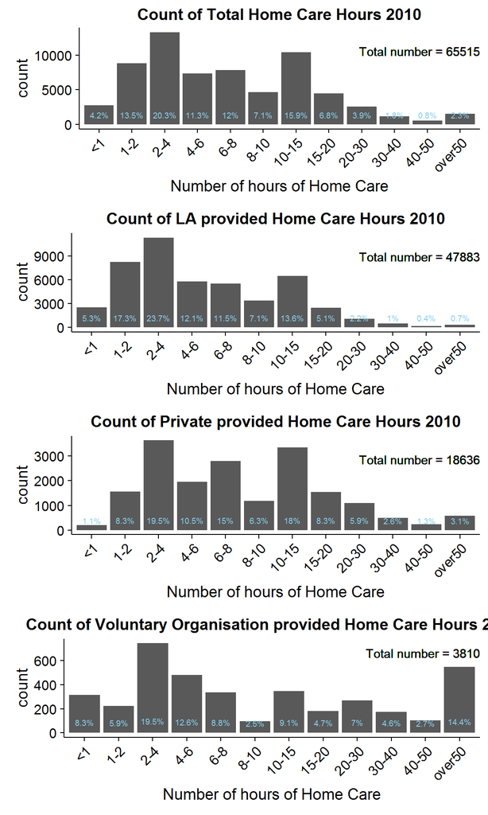

```r
plot_grid(hmcare_national, hmcare_LA, hmcare_pri, hmcare_vol, ncol = 1)
```

More recent reports on the Social Care Survey suggest that private and voluntary organisations tend to provide care for larger care packages (i.e. over 10 hrs.). This seems to be the case here but is difficult to se as it is a busy plot. I’d like to simplify these plots a little. Before I looked at the data I had thought I’d like to bin the hours into 0-5, 5-10, 10-15, 15-20, and 20 plus. Because of the way this data is grouped I can’t do that. For now I’ll go for 0-4 and 4-10 then carry on.

```r
hmcare_only2010_simplified$bandHRSLA <-
  fct_collapse(hmcare_only2010_simplified$bandHRSLA,
               `<4` = c("<1", "1-2", "2-4"),
               `4-10` = c("4-6", "6-8", "8-10"),
               over20 = c("20-30", "30-40", "40-50", "over50"))

hmcare_only2010_simplified$bandHRSpri <-
  fct_collapse(hmcare_only2010_simplified$bandHRSpri,
               `<4` = c("<1", "1-2", "2-4"),
               `4-10` = c("4-6", "6-8", "8-10"),
               over20 = c("20-30", "30-40", "40-50", "over50"))

hmcare_only2010_simplified$bandHRSvol <-
  fct_collapse(hmcare_only2010_simplified$bandHRSvol,
               `<4` = c("<1", "1-2", "2-4"),
               `4-10` = c("4-6", "6-8", "8-10"),
               over20 = c("20-30", "30-40", "40-50", "over50"))

hmcare_only2010_simplified$bandHRSTT <-
  fct_collapse(hmcare_only2010_simplified$bandHRSTT,
               `<4` = c("<1", "1-2", "2-4"),
               `4-10` = c("4-6", "6-8", "8-10"),
               over20 = c("20-30", "30-40", "40-50", "over50"))

hmcare_only2010_simplified$bandHRSPC <-
  fct_collapse(hmcare_only2010_simplified$bandHRSPC,
               `<4` = c("<1", "1-2", "2-4"),
               `4-10` = c("4-6", "6-8", "8-10"),
               over20 = c("20-30", "30-40", "40-50", "over50"))
```

Ok, now I’ll replot the above with the simplified levels.

```r
bandHRSTT10_simplifiedstats <-
  hmcare_only2010_simplified %>%
  filter(bandHRSTT != "Zero") %>%
  group_by(bandHRSTT) %>%
  summarise(count = n()) %>%
  mutate(pct = count/sum(count)*100)

hmcare_national_simplified <-
  hmcare_only2010_simplified %>%
  filter(bandHRSTT != "Zero") %>%
  ggplot(aes(x = bandHRSTT)) +
  geom_bar() +
  geom_text(data = bandHRSTT10_simplifiedstats, aes(label=paste0(round(pct,1),"%"),
                               y=pct), size=5, vjust = -1, colour = "sky blue") +
  geom_text(data = bandHRSTT10_simplifiedstats,
            aes(label=paste0("Total number = ",sum(count)), x = Inf, y= Inf,
                hjust = 1, vjust = 3)) +
  ggtitle("Count of Total Home Care Hours 2010") +
  xlab("Number of hours of Home Care") +
  theme(axis.text.x = element_text(size = 12,hjust = 1))
```

```r
bandHRSLA10_simplifiedstats <-
  hmcare_only2010_simplified %>%
  filter(bandHRSLA != "Zero") %>%
  group_by(bandHRSLA) %>%
  summarise(count = n()) %>%
  mutate(pct = count/sum(count)*100)

hmcare_LA_simplified <-
  hmcare_only2010_simplified %>%
  filter(bandHRSLA != "Zero") %>%
  ggplot(aes(x = bandHRSLA)) +
  geom_bar() +
  geom_text(data = bandHRSLA10_simplifiedstats, aes(label=paste0(round(pct,1),"%"),
                               y=pct), size=5, vjust = -1, colour = "sky blue") +
  geom_text(data = bandHRSLA10_simplifiedstats,
            aes(label=paste0("Total number = ",sum(count)), x = Inf, y= Inf,
                hjust = 1, vjust = 3)) +
  ggtitle("Count of LA provided Home Care Hours 2010") +
  xlab("Number of hours of Home Care") +
  theme(axis.text.x = element_text(size = 12,hjust = 1))
```

```r
bandHRSpri10_simplifiedstats <-
  hmcare_only2010_simplified %>%
  filter(bandHRSpri != "Zero") %>%
  group_by(bandHRSpri) %>%
  summarise(count = n()) %>%
  mutate(pct = count/sum(count)*100)

hmcare_pri_simplified <-
  hmcare_only2010_simplified %>%
  filter(bandHRSpri != "Zero") %>%
  ggplot(aes(x = bandHRSpri)) +
  geom_bar() +
  geom_text(data = bandHRSpri10_simplifiedstats, aes(label=paste0(round(pct,1),"%"),
                               y=pct), size=5, vjust = -1, colour = "sky blue") +
  geom_text(data = bandHRSpri10_simplifiedstats,
            aes(label=paste0("Total number = ",sum(count)), x = Inf, y= Inf,
                hjust = 1, vjust = 3)) +
  ggtitle("Count of Private provided Home Care Hours 2010") +
  xlab("Number of hours of Home Care") +
  theme(axis.text.x = element_text(size = 12,hjust = 1))
```

```r
bandHRSvol10_simplifiedstats <-
  hmcare_only2010_simplified %>%
  filter(bandHRSvol != "Zero") %>%
  group_by(bandHRSvol) %>%
  summarise(count = n()) %>%
  mutate(pct = count/sum(count)*100)

hmcare_vol_simplified<-
  hmcare_only2010_simplified %>%
  filter(bandHRSvol != "Zero") %>%
  ggplot(aes(x = bandHRSvol)) +
  geom_bar() +
  geom_text(data = bandHRSvol10_simplifiedstats, aes(label=paste0(round(pct,1),"%"),
                               y=pct), size= 5, vjust = -1, colour = "sky blue") +
  geom_text(data = bandHRSvol10_simplifiedstats,
            aes(label=paste0("Total number = ",sum(count)), x = Inf, y= Inf,
                hjust = 1, vjust = 2)) +
  ggtitle("Count of Voluntary Organisation provided Home Care Hours 2010") +
  xlab("Number of hours of Home Care") +
  theme(axis.text.x = element_text(size = 12,hjust = 1))
```

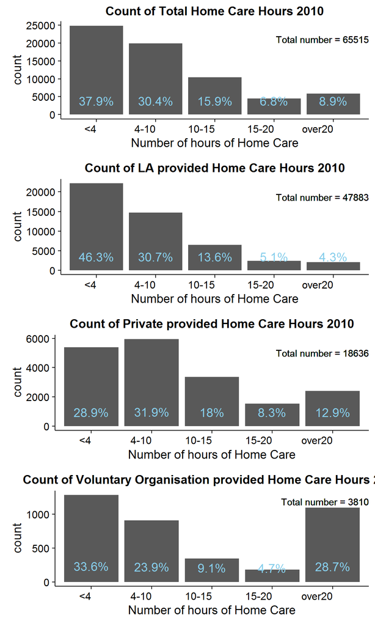

```r
library(cowplot)
plot_grid(hmcare_national_simplified, hmcare_LA_simplified, hmcare_pri_simplified,
          hmcare_vol_simplified, ncol = 1)
```

So this makes the distinction a lot esasier to see. With this simplified plot we can see Local Authorities on the whole tend to concentrate on providing smaller care packages with the private, and particularly voluntary, sectors picking up a greater proportion of the larger packages of care.

### Distribution by Age

With these simplified groups I’ll now have a look at the distribution of Total number of home care hours by Age Group

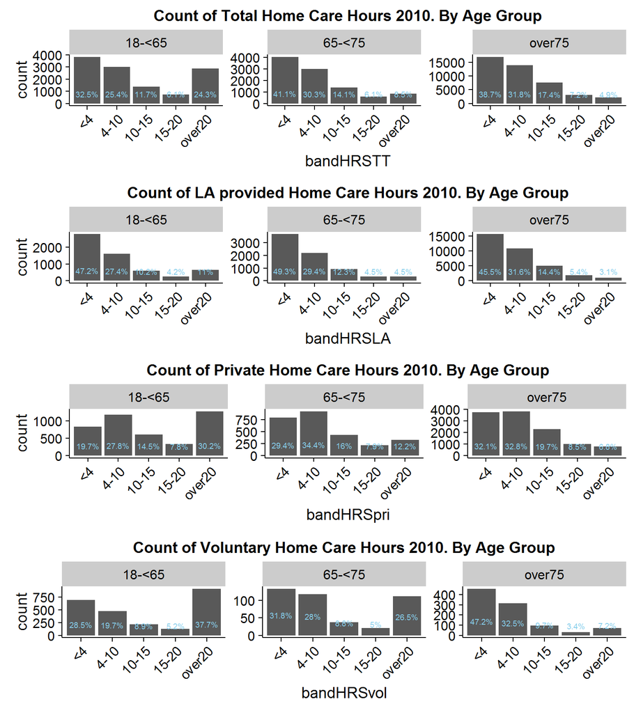

```r
bandHRSTTstats_byAge <-
  hmcare_only2010_simplified %>%
  filter(bandHRSTT != "Zero") %>%
  filter(AgeGRP != "Unknown") %>%
  group_by(AgeGRP, bandHRSTT) %>%
  summarise(count = n()) %>%
  mutate(pct = count/sum(count) * 100)

bandHRSTT_byAge <-
  hmcare_only2010_simplified %>%
  filter(bandHRSTT != "Zero") %>%
  filter(AgeGRP != "Unknown") %>%
  ggplot(aes(x=bandHRSTT)) +
  geom_bar() +
  facet_wrap(~AgeGRP, scales = "free") +
  geom_text(data = bandHRSTTstats_byAge, aes(label=paste0(round(pct,1),"%"),
                               y=pct), size=2.5, vjust = -1, colour = "sky blue") +
  ggtitle("Count of Total Home Care Hours 2010. By Age Group") +
  theme(axis.text.x = element_text(angle = 45, size = 12, hjust = 1))

bandHRSLAstats_byAge <-
  hmcare_only2010_simplified %>%
  filter(bandHRSLA != "Zero") %>%
  filter(AgeGRP != "Unknown") %>%
  group_by(AgeGRP, bandHRSLA) %>%
  summarise(count = n()) %>%
  mutate(pct = count/sum(count) * 100)

bandHRSLA_byAge <-
  hmcare_only2010_simplified %>%
  filter(bandHRSLA != "Zero") %>%
  filter(AgeGRP != "Unknown") %>%
  ggplot(aes(x=bandHRSLA)) +
  geom_bar() +
  facet_wrap(~AgeGRP, scales = "free") +
  geom_text(data = bandHRSLAstats_byAge, aes(label=paste0(round(pct,1),"%"),
                               y=pct), size=2.5, vjust = -1, colour = "sky blue") +
  ggtitle("Count of LA provided Home Care Hours 2010. By Age Group") +
  theme(axis.text.x = element_text(angle = 45, size = 12, hjust = 1))

bandHRSpristats_byAge <-
  hmcare_only2010_simplified %>%
  filter(bandHRSpri != "Zero") %>%
  filter(AgeGRP != "Unknown") %>%
  group_by(AgeGRP, bandHRSpri) %>%
  summarise(count = n()) %>%
  mutate(pct = count/sum(count) * 100)

bandHRSpri_byAge <-
  hmcare_only2010_simplified %>%
  filter(bandHRSpri != "Zero") %>%
  filter(AgeGRP != "Unknown") %>%
  ggplot(aes(x=bandHRSpri)) +
  geom_bar() +
  facet_wrap(~AgeGRP, scales = "free") +
  geom_text(data = bandHRSpristats_byAge, aes(label=paste0(round(pct,1),"%"),
                               y=pct), size=2.5, vjust = -1, colour = "sky blue") +
  ggtitle("Count of Private Home Care Hours 2010. By Age Group") +
  theme(axis.text.x = element_text(angle = 45, size = 12, hjust = 1))

bandHRSvolstats_byAge <-
  hmcare_only2010_simplified %>%
  filter(bandHRSvol != "Zero") %>%
  filter(AgeGRP != "Unknown") %>%
  group_by(AgeGRP, bandHRSvol) %>%
  summarise(count = n()) %>%
  mutate(pct = count/sum(count) * 100)

bandHRSvol_byAge <-
  hmcare_only2010_simplified %>%
  filter(bandHRSvol != "Zero") %>%
  filter(AgeGRP != "Unknown") %>%
  ggplot(aes(x=bandHRSvol)) +
  geom_bar() +
  facet_wrap(~AgeGRP, scales = "free") +
  geom_text(data = bandHRSvolstats_byAge, aes(label=paste0(round(pct,1),"%"),
                               y=pct), size=2.5, vjust = -1, colour = "sky blue") +
  ggtitle("Count of Voluntary Home Care Hours 2010. By Age Group") +
  theme(axis.text.x = element_text(angle = 45, size = 12, hjust = 1))

plot_grid(bandHRSTT_byAge, bandHRSLA_byAge, bandHRSpri_byAge, bandHRSvol_byAge, ncol = 1)
```

### Distribution by Gender

I’ll just look at the Total hours by Gender.

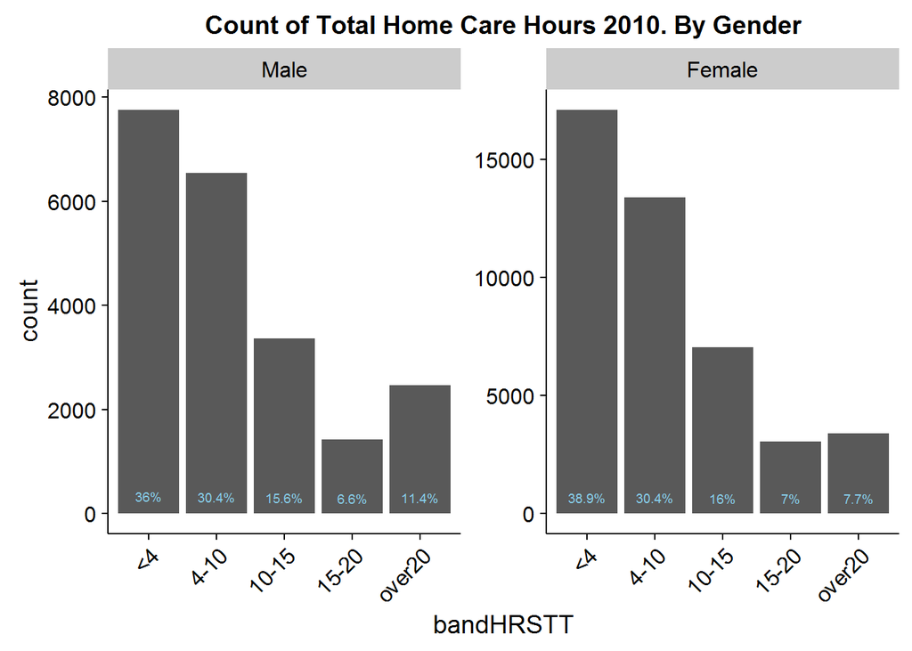

```r
bandHRSTTstats_byGender <-
  hmcare_only2010_simplified %>%
  filter(bandHRSTT != "Zero") %>%
  group_by(GenderISO, bandHRSTT) %>%
  summarise(count = n()) %>%
  mutate(pct = count/sum(count) * 100)

bandHRSTT_byGender <-
  hmcare_only2010_simplified %>%
  filter(bandHRSTT != "Zero") %>%
  ggplot(aes(x=bandHRSTT)) +
  geom_bar() +
  facet_wrap(~GenderISO, scales = "free") +
  geom_text(data = bandHRSTTstats_byGender, aes(label=paste0(round(pct,1),"%"),
                               y=pct), size=2.5, vjust = -1, colour = "sky blue") +
  ggtitle("Count of Total Home Care Hours 2010. By Gender") +
  theme(axis.text.x = element_text(angle = 45, size = 12, hjust = 1))
bandHRSTT_byGender
```

So the distibution across gender seems pretty similar with a slight increase in the proportion of Men getting over 20 hr packages.(Wild stab in the dark - More men with Aquired Brain injury from traffic accidents/fights etc).

### Distribution across Local Authorities

The next really interesting question is how home care hours vary across LAs. For now we will stick to the Total hours only and leave out the breakdown by provider.

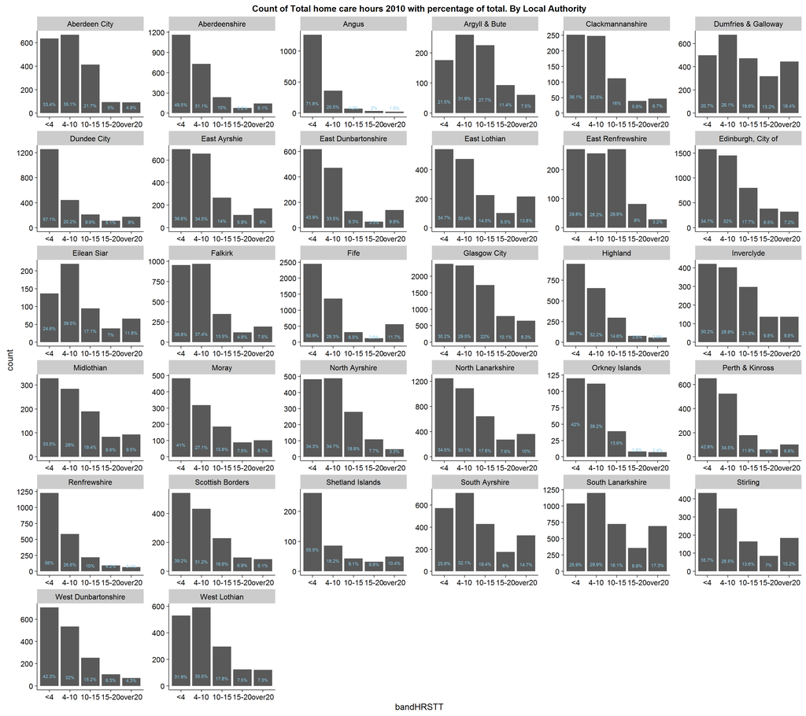

```r
bandHRSTT10stats_byLA <-
  hmcare_only2010_simplified %>%
  group_by(LAcode, bandHRSTT) %>%
  summarise(count = n()) %>%
  mutate(pct=count/sum(count)*100)

bandHRSTTplot_LA <-
  hmcare_only2010_simplified %>%
  ggplot(aes(x = bandHRSTT)) +
  geom_bar() +
  facet_wrap(~LAcode, scales = "free") +
  geom_text(data = bandHRSTT10stats_byLA, aes(label=paste0(round(pct,1),"%"), y=pct),
            size=2.5, vjust = -1, colour = "sky blue") +
  ggtitle("Count of Total home care hours 2010 with percentage of total. By Local Authority")
bandHRSTTplot_LA
```

Ok. Some really big variations here. Particularly in the <4hrs banding - from 20% in Dumfries & Galloway to 70% in Angus.

Again, a stacked bar chart will be useful here…

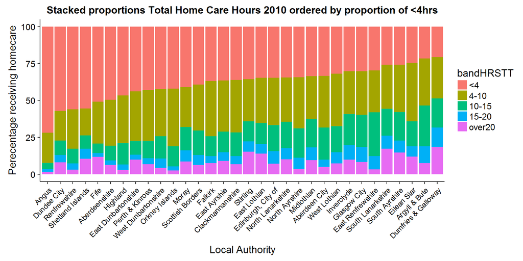

```r
ordered_bandHRSTT <-                   #Create a vector with LAs ordered by over 75s
  bandHRSTT10stats_byLA %>%
  arrange(bandHRSTT, -pct)
ordered_LAs_bandHRSTT <- ordered_bandHRSTT$LAcode[1:32] # Order by <4

bandHRSTT_stacked_LA <-
  ggplot(bandHRSTT10stats_byLA, aes(x = LAcode, y = pct, fill = bandHRSTT)) +
  geom_col(position = "stack") +
  scale_x_discrete(limits = ordered_LAs_bandHRSTT) +   #using above vector
  theme(axis.text.x = element_text(angle = 45, size = 10, hjust = 1)) +
  ggtitle("Stacked proportions Total Home Care Hours 2010 ordered by proportion of <4hrs") +
  xlab("Local Authority") +
  ylab("Perecentage receiving homecare")
bandHRSTT_stacked_LA
```

Certainly shows the variation nicely!

I’ll try and see if Age has any impact on this variation.

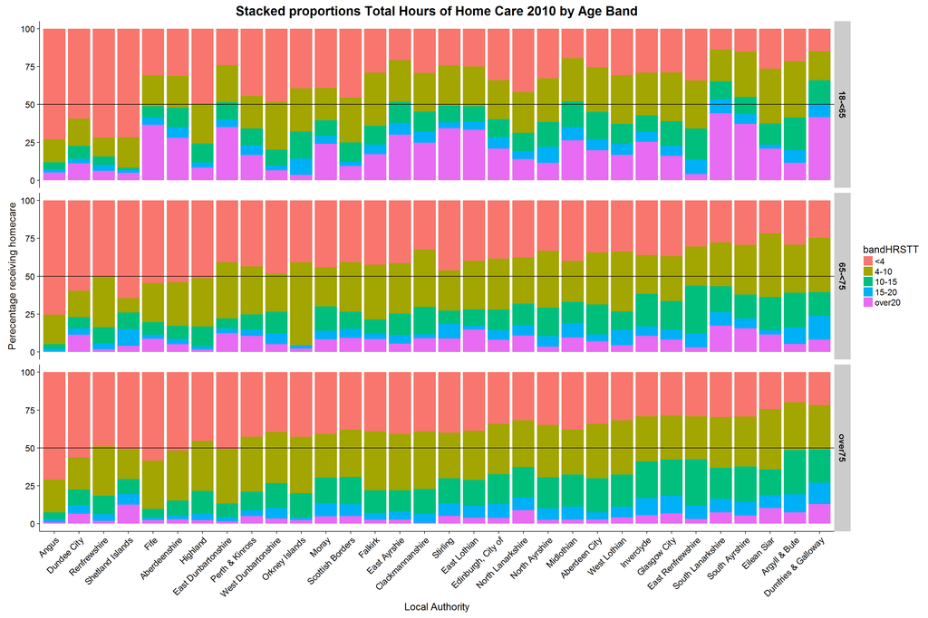

```r
bandHRSTT10stats_byLA_byAge <-
  hmcare_only2010_simplified %>%
  filter(HCclient == "Yes") %>%
  group_by(LAcode,AgeGRP, bandHRSTT) %>%
  summarise(count = n()) %>%
  mutate(pct = count/sum(count) * 100)

bandHRSTT_stacked_LA_byAge <-
  bandHRSTT10stats_byLA_byAge %>%
  filter(bandHRSTT != "Zero") %>%
  filter(AgeGRP != "Unknown") %>%
  ggplot(aes(x = LAcode, y = pct, fill = bandHRSTT)) +
  geom_col(position = "stack") +
  facet_grid(AgeGRP ~ .) +
  geom_hline(yintercept = 50) +
  scale_x_discrete(limits = ordered_LAs_bandHRSTT) +
  ggtitle("Stacked proportions Total Hours of Home Care 2010 by Age Band") +
  xlab("Local Authority") +
  ylab("Perecentage receiving homecare") +
  theme(plot.title = element_text(size = 18, face = "bold")) +
  theme(axis.text.x = element_text(angle = 45, size = 12,hjust = 1)) +
  theme(axis.title = element_text(size = 14)) +
  theme(strip.text.y = element_text(size=12, face="bold"))
bandHRSTT_stacked_LA_byAge
```

## Living arrangements

### National Distribution

What are the living arrangements of those receiving Home Care?

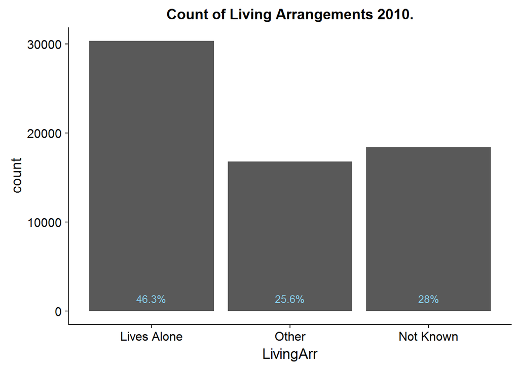

```r
LivingArrstats <-                      #Create a table with summary stats to use as labels
  hmcare_only2010 %>%                  #in the plot
  group_by(LivingArr) %>%              #Group main df by LivingArr
  summarise(count = n()) %>%           #Count individuals in each age group - new column
  mutate(pct = count/sum(count)*100)   #New column - with percentage calculated

LivingArr_plot_national <-                   #Plot Age group from main hmcare2010 df.
  ggplot(hmcare_only2010,aes(x = LivingArr)) +
  geom_bar() +
  geom_text(data = LivingArrstats, aes(label=paste0(round(pct,1),"%"), #Add labels from above
                               y=pct), size=3.5, vjust = -1, colour = "sky blue") +
  ggtitle("Count of Living Arrangements 2010.")
LivingArr_plot_national
```

So the pre-banding isn’t helpful here - Data is collected on sheltered housing and care homes I believe. It is possible numbers are so small that they cannot be disclosed. Quite a bit of missing data here. Any Age or Gender more likely to be missing?

### Distribution by Age

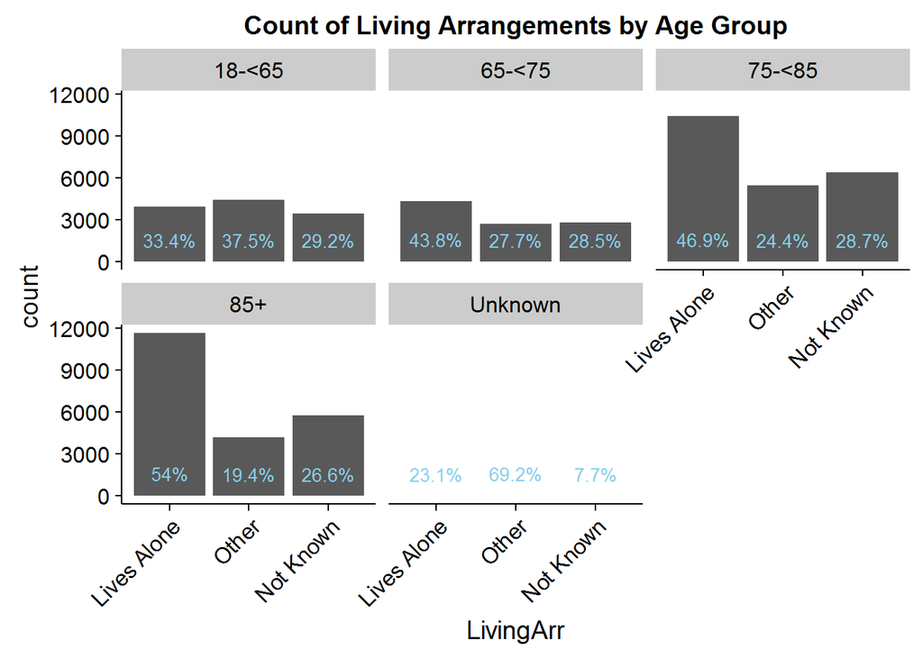

```r
LivingArr_byAgestats <-                #Create a table with summary stats to use as labels
  hmcare_only2010 %>%                  #in the plot
  group_by(AgeGRP, LivingArr) %>%      #Group main df by Age and LivingArr
  summarise(count = n()) %>%           #Count individuals in each age group - new column
  mutate(pct = count/sum(count)*100)   #New column - with percentage calculated

LivingArr_byAge_plot_national <-        #Plot Age group from main hmcare2010 df.
  ggplot(hmcare_only2010,aes(x = LivingArr)) +
  geom_bar() +
  facet_wrap(~AgeGRP) +
  geom_text(data = LivingArr_byAgestats, aes(label=paste0(round(pct,1),"%"),
                               y=pct), size=3.5, vjust = -1, colour = "sky blue") +
  theme(axis.text.x = element_text(angle = 45, size = 12,hjust = 1)) +
  ggtitle("Count of Living Arrangements by Age Group")
LivingArr_byAge_plot_national
```

So similar amount of missing data here across Age groups. What about Gender?

### Distribution by Gender

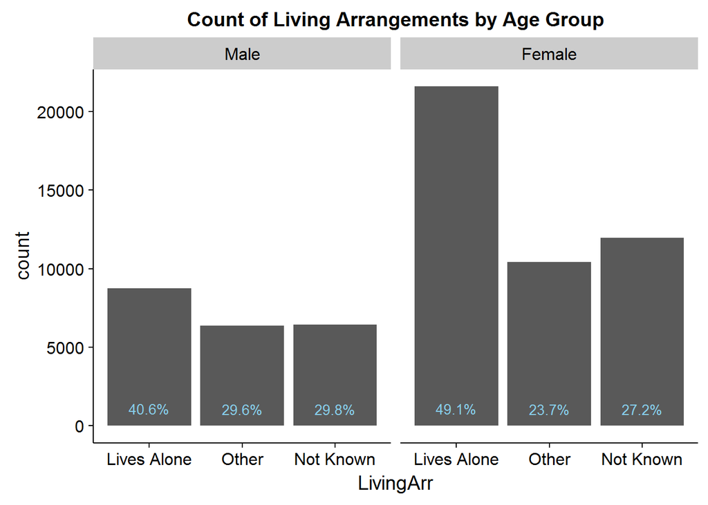

```r
LivingArr_byGenderstats <-             #Create a table with summary stats to use as labels
  hmcare_only2010 %>%                  #in the plot
  group_by(GenderISO, LivingArr) %>%   #Group main df by Age and LivingArr
  summarise(count = n()) %>%           #Count individuals in each age group - new column
  mutate(pct = count/sum(count)*100)   #New column - with percentage calculated

LivingArr_byGender_plot_national <-        #Plot Age group from main hmcare2010 df.
  ggplot(hmcare_only2010,aes(x = LivingArr)) +
  geom_bar() +
  facet_wrap(~GenderISO) +
  geom_text(data = LivingArr_byGenderstats, aes(label=paste0(round(pct,1),"%"),
                               y=pct), size=3.5, vjust = -1, colour = "sky blue") +
  ggtitle("Count of Living Arrangements by Age Group")
LivingArr_byGender_plot_national
```

So women getting home care are more liekly to be living alone. No major difference in missingness - are there certain LAs more culpable??

### Distribution by LA

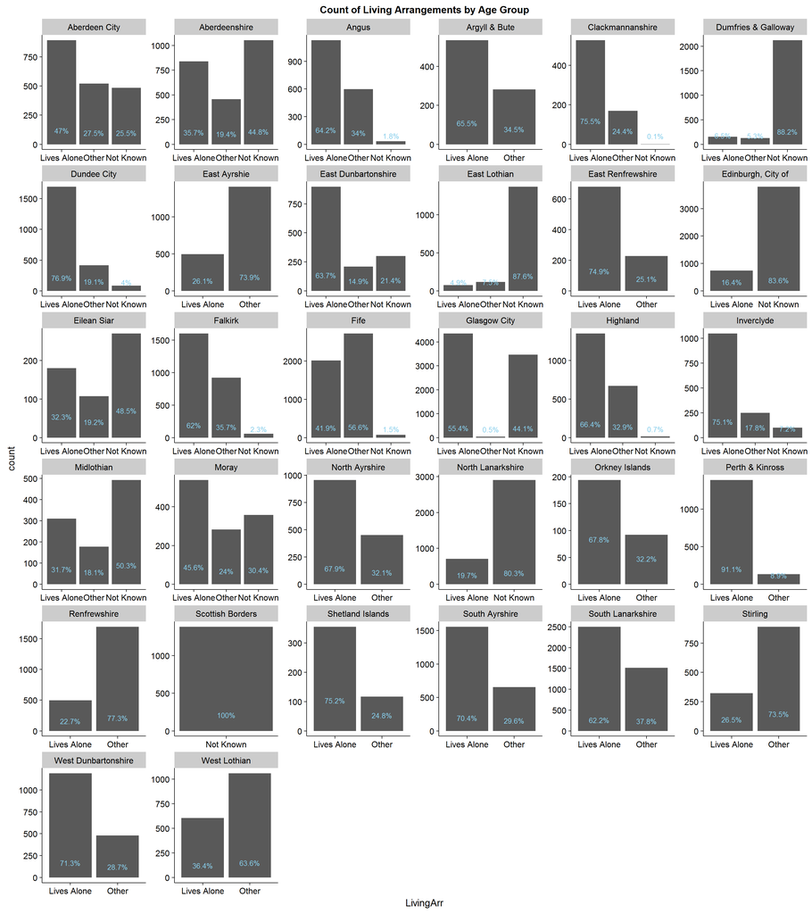

```r
LivingArr_byLAstats <-             #Create a table with summary stats to use as labels
  hmcare_only2010 %>%                  #in the plot
  group_by(LAcode, LivingArr) %>%   #Group main df by Age and LivingArr
  summarise(count = n()) %>%           #Count individuals in each age group - new column
  mutate(pct = count/sum(count)*100)   #New column - with percentage calculated

LivingArr_byLA_plot_national <-        #Plot Age group from main hmcare2010 df.
  ggplot(hmcare_only2010,aes(x = LivingArr)) +
  geom_bar() +
  facet_wrap(~LAcode, scales = "free") +
  geom_text(data = LivingArr_byLAstats, aes(label=paste0(round(pct,1),"%"),
                               y=pct), size=3.5, vjust = -1, colour = "sky blue") +
  ggtitle("Count of Living Arrangements by Age Group")
LivingArr_byLA_plot_national
```

All-in-all another unreliable variable I would say.

## Other services

How many clients that receive home care also receive another service?

### Meals

```r
fct_count(hmcare_only2010$meals)
```

```
## # A tibble: 2 × 2
##          f     n
##     <fctr> <int>
## 1 No meals 58373
## 2    Meals  7142
```